# DATA 624: Homework 8

Andrew Bowen

2024-04-02

```r
library(tidyverse)
library(MASS)
library(caret)
library(mlbench)
library(xgboost)
library(GGally)
library(e1071)
library(corrplot)
```

## Exercise 7.2 (K&J)

Let’s create the simulated data from *Friedman* using the same bit of code to generate the simulated data. We’ll also create the feature distribution plot in the same manner as the text.

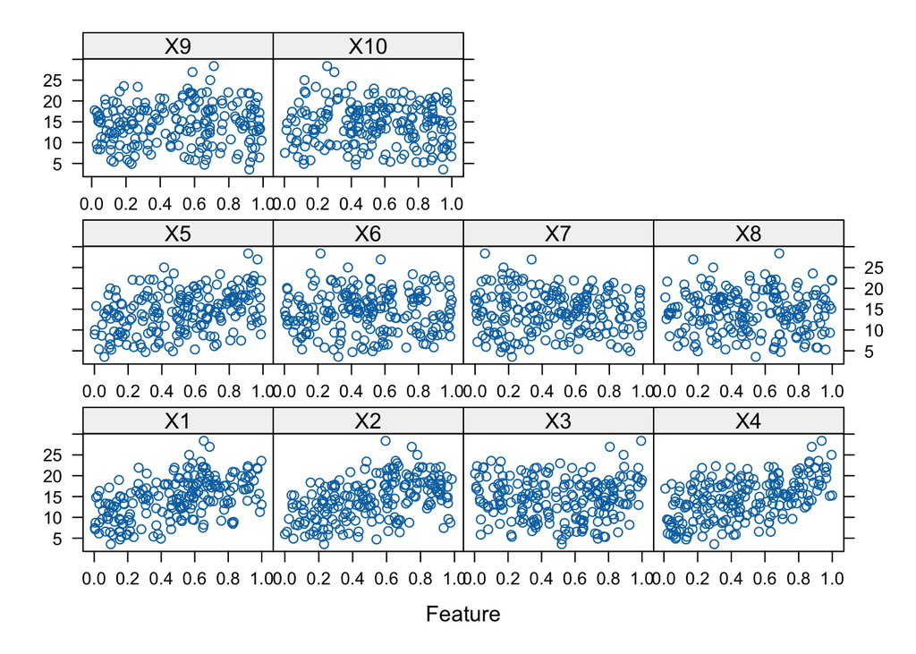

```r
set.seed(200)
trainingData <- mlbench.friedman1(200, sd = 1)

trainingData$x <- data.frame(trainingData$x)

featurePlot(trainingData$x, trainingData$y)
```

```r
# Set up test data
testData <- mlbench.friedman1(5000, sd = 1)
testData$x <- data.frame(testData$x)
```

Before we model, let’s get a summary of both our training features and test data, plotting them via `ggpairs`.

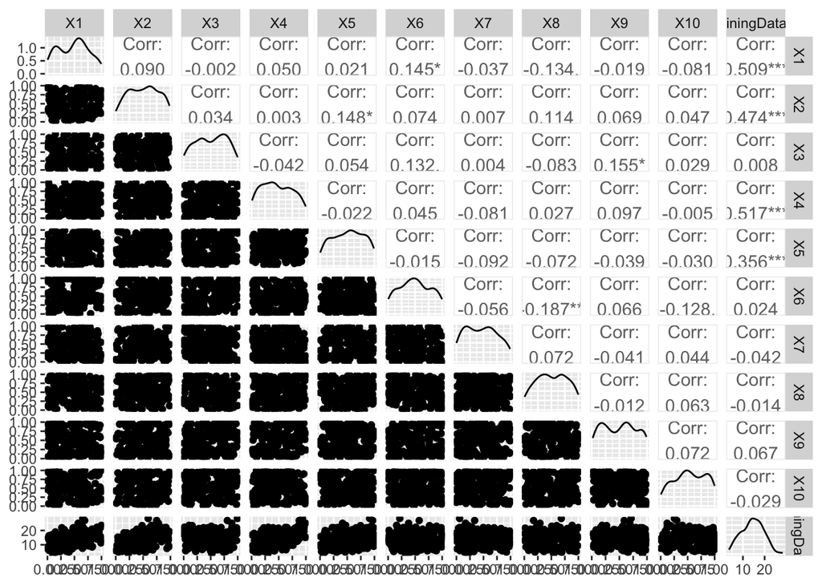

```r
# Plot training data distributions
ggpairs(cbind(trainingData$x, trainingData$y))
```

While the scatter plots are a bit busy, we see *some* relatively normally distributed features.

```r
# library(caret)
knnModel <- train(x = trainingData$x,
                   y = trainingData$y,
                   method = "knn",
                   preProc = c("center", "scale"))

knnModel
```

```
## k-Nearest Neighbors
##
## 200 samples
##  10 predictor
##
## Pre-processing: centered (10), scaled (10)
## Resampling: Bootstrapped (25 reps)
## Summary of sample sizes: 200, 200, 200, 200, 200, 200, ...
## Resampling results across tuning parameters:
##
##   k  RMSE      Rsquared   MAE
##   5  3.466085  0.5121775  2.816838
##   7  3.349428  0.5452823  2.727410
##   9  3.264276  0.5785990  2.660026
##
## RMSE was used to select the optimal model using the smallest value.
## The final value used for the model was k = 9.
```

Now we’ll actually predict against our test data using the KNN model. We’ll print out the root-mean squared error as well, which is a diagnostic metric we can use to evaluate the efficacy of a regression model.

```r
knnPred <- predict(knnModel, testData$x)

RMSE(knnPred, testData$y)
```

```
## [1] 3.117232
```

Let’s train a decision tree on our data as well. Decision trees can be robust models, but are often prone to overfiting on training data.

```r
decisionTreeModel <- train(x=trainingData$x,
                 y=trainingData$y,
                 method="rpart",
                 tuneLength=10)
decisionTreeModel
```

```
## CART
##
## 200 samples
##  10 predictor
##
## No pre-processing
## Resampling: Bootstrapped (25 reps)
## Summary of sample sizes: 200, 200, 200, 200, 200, 200, ...
## Resampling results across tuning parameters:
##
##   cp          RMSE      Rsquared   MAE
##   0.01228972  3.678817  0.4809688  2.990114
##   0.01387981  3.686479  0.4774770  2.997159
##   0.01429458  3.695995  0.4747507  3.007059
##   0.02618043  3.712253  0.4625909  3.033527
##   0.03515931  3.792122  0.4356117  3.101091
##   0.05860160  3.983127  0.3854415  3.270421
##   0.06528495  4.061607  0.3651742  3.339100
##   0.07513824  4.135943  0.3429854  3.392170
##   0.20070359  4.596144  0.1871626  3.794009
##   0.25672400  4.706893  0.1682766  3.883181
##
## RMSE was used to select the optimal model using the smallest value.
## The final value used for the model was cp = 0.01228972.
```

```r
# Predict using decision tree
predictTree <- predict(decisionTreeModel, testData$x)

RMSE(predictTree, testData$y)
```

```
## [1] 3.381563
```

We’ll also train a MARS model similar to the method employed in K&J.

```r
# Train spline model (MARS)
marsGrid <- expand.grid(.degree = 1:2, .nprune = 2:38)
marsTuned <- train(x=trainingData$x,
                   y=trainingData$y, method = "earth", tuneGrid = marsGrid,
                   trControl = trainControl(method = "cv"))
marsTuned
```

```
## Multivariate Adaptive Regression Spline
##
## 200 samples
##  10 predictor
##
## No pre-processing
## Resampling: Cross-Validated (10 fold)
## Summary of sample sizes: 180, 180, 180, 180, 180, 180, ...
## Resampling results across tuning parameters:
##
##   degree  nprune  RMSE      Rsquared   MAE
##   1        2      4.327437  0.2666502  3.6133264
##   1        3      3.582260  0.5145400  2.9105565
##   1        4      2.640676  0.7227538  2.1614949
##   1        5      2.292028  0.8062647  1.8481401
```

[output cut: 73 more lines]

We’ll predict using the MARS model to see the RMSE on testing data

```r
predictMars <- predict(marsTuned, testData$x)

RMSE(predictMars, testData$y)
```

```
## [1] 1.158995
```

We can use the `varImp` function to see which are the most important features for a given model. In the case of our MARS model, we can see that the informative predictors (`X1 - X5`) are in fact selected

```r
varImp(marsTuned)
```

```
## earth variable importance
##
##    Overall
## X1  100.00
## X4   75.24
## X2   48.73
## X5   15.52
## X3    0.00
```

Lastly, let’s try to train an XGBoost (Gradient Boosting), we can use the [`xgboost` library within R to do so](https://xgboost.readthedocs.io/en/stable/R-package/xgboostPresentation.html). XGBoost can be used for both regression and classification tasks.

```r
# Train XGBoost model
xgBoosetModel <- xgboost(data = as.matrix(trainingData$x),
                         label = as.matrix(trainingData$y),
                         max.depth = 2, eta = 1, nthread = 2,
                         nrounds = 2)
xgBoosetModel
```

```
## ##### xgb.Booster
## raw: 5.8 Kb
## call:
##   xgb.train(params = params, data = dtrain, nrounds = nrounds,
##     watchlist = watchlist, verbose = verbose, print_every_n = print_every_n,
##     early_stopping_rounds = early_stopping_rounds, maximize = maximize,
##     save_period = save_period, save_name = save_name, xgb_model = xgb_model,
##     callbacks = callbacks, max.depth = 2, eta = 1, nthread = 2)
## params (as set within xgb.train):
##   max_depth = "2", eta = "1", nthread = "2", validate_parameters = "1"
## xgb.attributes:
##   niter
## callbacks:
##   cb.print.evaluation(period = print_every_n)
##   cb.evaluation.log()
## # of features: 10
## niter: 2
## nfeatures : 10
## evaluation_log:
##   iter train_rmse
##  <num>      <num>
##      1   3.478113
##      2   2.661574
```

In terms of purely RMSE when predicting against our test data, we see the best performance from the MARS model.

## Exercise 7.5 (K&J)

```r
# Load chemical data
library(AppliedPredictiveModeling)
library(kernlab)
library(earth)
library(nnet)
library(ModelMetrics)
data("ChemicalManufacturingProcess")

chemical <- ChemicalManufacturingProcess
chemical_features <- chemical %>% dplyr::select(-c("Yield"))
```

We’ll impute this data the same way we did in HW7

```r
# Impute chemical yield data
imputed <- preProcess(chemical,
                       method = c("knnImpute"))

trans <- predict(imputed, chemical)
```

We’ll also set up a train-test split as well

```r
# Split into train and test splits
#use 75% of dataset as training set and 30% as test set
sample <- sample(c(TRUE, FALSE), nrow(trans), replace=TRUE, prob=c(0.8,0.2))
train  <- trans[sample, ]
train_yield <- train$Yield
train <- train %>%
  dplyr::select(-c("Yield"))
test <- trans[!sample, ]
test_yield <- test$Yield
test <- test  %>%
  dplyr::select(-c("Yield"))
```

Now we can try a spline regression model similar to how it’s done in K&J

```r
marsGrid <- expand.grid(.degree = 1:2, .nprune = 2:20)
marsTuned <- train(x = train,
                   y = train_yield,
                   method = "earth", tuneGrid =marsGrid,
trControl = trainControl(method = "cv"))

marsTuned
```

```
## Multivariate Adaptive Regression Spline
##
## 133 samples
##  57 predictor
##
## No pre-processing
## Resampling: Cross-Validated (10 fold)
## Summary of sample sizes: 120, 117, 120, 120, 120, 120, ...
## Resampling results across tuning parameters:
##
##   degree  nprune  RMSE       Rsquared   MAE
##   1        2      0.8255218  0.4255589  0.6448691
##   1        3      0.7076756  0.5594258  0.5588394
##   1        4      0.6829418  0.5905764  0.5398365
##   1        5      0.6777599  0.6074488  0.5355634
```

[output cut: 37 more lines]

We can plot our spline model, and we see the resulting errors over our cross-validation folds.

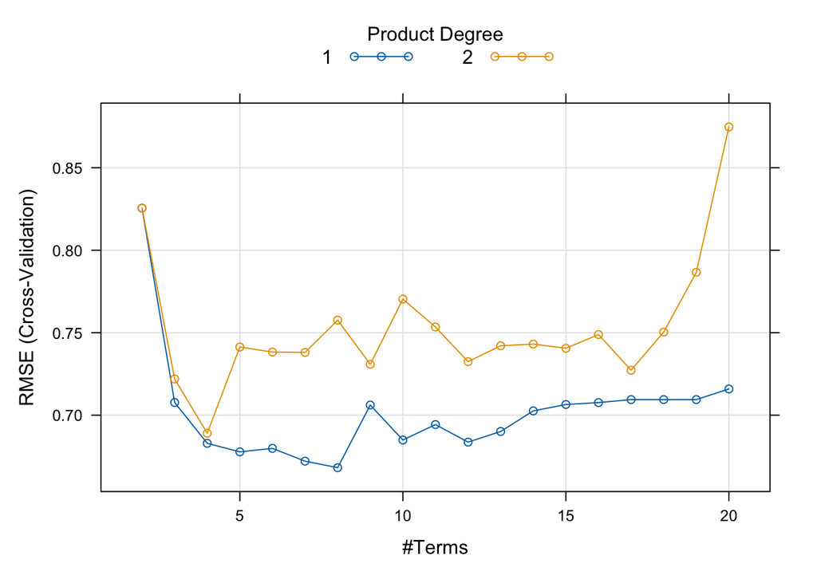

```r
plot(marsTuned)
```

```r
# train a support vector
svmFit <- train(train, train_yield, method = "svmRadial",
                    preProc = c("center", "scale"), tuneLength = 15,
                    trControl = trainControl(method = "cv"))


svmFit$resample
```

```
##         RMSE  Rsquared       MAE Resample
## 1  0.8283012 0.4484280 0.7332573   Fold01
## 2  0.6631408 0.6081640 0.5371689   Fold03
## 3  0.5995672 0.7343060 0.5107410   Fold09
## 4  0.8339779 0.6160227 0.5526669   Fold02
## 5  0.4961339 0.7891719 0.3857777   Fold10
## 6  0.5396032 0.7705326 0.4690446   Fold05
## 7  0.5103868 0.8048235 0.4289214   Fold06
## 8  0.6169507 0.7511327 0.4705829   Fold04
## 9  0.6631854 0.6691171 0.5466585   Fold07
## 10 0.5388635 0.6775118 0.4165972   Fold08
```

We can get the RMSE of our SVM regression model based on the predicted alues compared against the testing values

```r
rmse(predict(svmFit, test), test_yield)
```

```
## [1] 0.5324566
```

We can also train a KNN regression model to predict the `Yield` output variable

```r
knnTune <- train(train,
                 train_yield,
                 method = "knn",
                 preProc = c("center", "scale"), # setting this in the model training will make it occur for testing as well
                 tuneGrid = data.frame(.k = 1:20),
                 trControl = trainControl(method = "cv"))
```

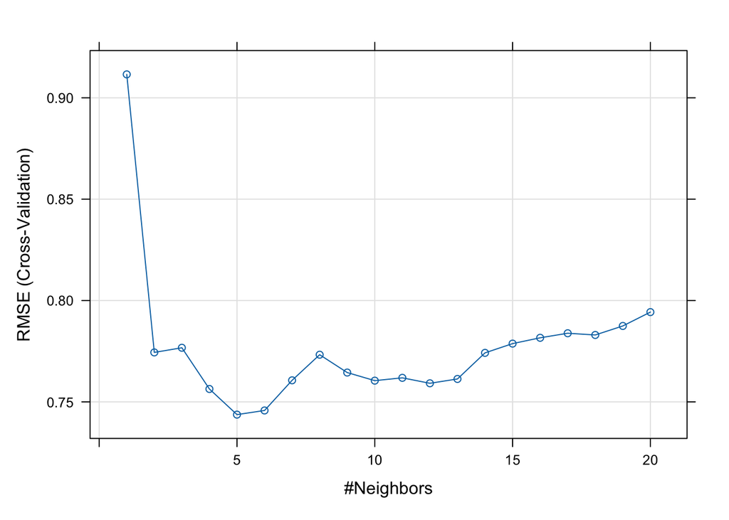

```r
plot(knnTune)
```

Lastly, we’ll train a neural net model on our checmical processing data

```r
nnetFit <- train(train, train_yield,
                  method = "nnet",
                 tuneLength=10,
                 preProc = c("center", "scale"), trace = FALSE,
                trControl = trainControl(method = "cv"))
```

```r
nnPred <- predict(nnetFit, test)

nnetFit$results
```

```
##     size        decay      RMSE   Rsquared       MAE     RMSESD RsquaredSD
## 1      1 0.0000000000 1.0446689        NaN 0.8647718 0.11687754         NA
## 2      1 0.0001000000 0.9602047 0.35370438 0.7924751 0.13091826 0.14532767
## 3      1 0.0002371374 0.9499226 0.41670304 0.7820682 0.12074066 0.16328378
## 4      1 0.0005623413 0.8694557 0.49612601 0.7036847 0.13923502 0.18220159
## 5      1 0.0013335214 0.8415267 0.54236859 0.6788265 0.12621286 0.17267371
## 6      1 0.0031622777 0.8747694 0.46345512 0.7154521 0.10029505 0.10555984
## 7      1 0.0074989421 0.8801878 0.48722454 0.7207901 0.11207299 0.17585171
## 8      1 0.0177827941 0.8584324 0.51926562 0.6996166 0.12934376 0.16808123
## 9      1 0.0421696503 0.8759545 0.48453574 0.7177421 0.11902629 0.13898627
## 10     1 0.1000000000 0.8789621 0.48627958 0.7193764 0.13055838 0.13706046
## 11     3 0.0000000000 1.0446689        NaN 0.8647718 0.11687754         NA
## 12     3 0.0001000000 0.8851309 0.43581928 0.7255324 0.15429023 0.18578804
## 13     3 0.0002371374 0.9232621 0.44065404 0.7628656 0.17176893 0.19586877
## 14     3 0.0005623413 0.8798274 0.47550108 0.7181215 0.12910418 0.15554495
```

[output cut: 187 more lines]

Let’s use the `varImp` function to see which feature variables in our fit are most consequential

```r
(importance <- varImp(nnetFit))
```

```
## nnet variable importance
##
##   only 20 most important variables shown (out of 57)
##
##                        Overall
## ManufacturingProcess32  100.00
## ManufacturingProcess36   59.73
## ManufacturingProcess28   52.69
## ManufacturingProcess39   49.31
## ManufacturingProcess24   48.18
## ManufacturingProcess13   41.22
## ManufacturingProcess22   39.64
## ManufacturingProcess37   39.31
## ManufacturingProcess35   35.03
## ManufacturingProcess12   34.99
## ManufacturingProcess04   32.40
## ManufacturingProcess05   31.69
## ManufacturingProcess33   31.53
## ManufacturingProcess01   31.46
## ManufacturingProcess03   30.67
## BiologicalMaterial10     29.40
## BiologicalMaterial02     27.86
## ManufacturingProcess08   27.54
## ManufacturingProcess43   26.51
## ManufacturingProcess07   26.24
```

We see the variable for our neural network that’s most important is the `ManufacturingProcess32`. In fact, we see the Manufacturing variables dominate the top 10 most important variables for this fit. This is the same as the case of the linear models trained in Exercise 6.3, in which manufacturing process variables had a higher influence.

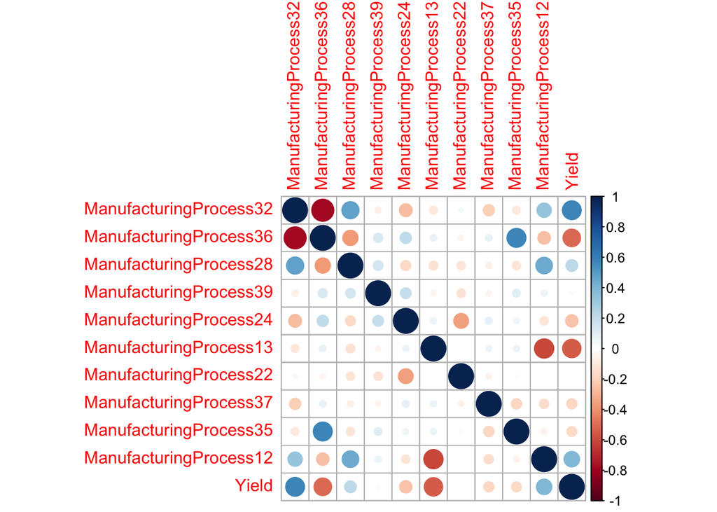

```r
# Get top-10 feature names
importance <- importance$importance
importance$feature <- rownames(importance)
importance <- importance[order(importance$Overall, decreasing=TRUE), ]

# Get importance feature names
important_features <- rownames(head(importance, 10))

# Create correllelogram of imputed chemical data
correlation <- cor(imputed$data[, c(important_features, "Yield")])
corrplot(correlation)
```